# AnalisisASPC_ANN

Arya Candra

5/2/2022

# Load Data

```r
library(tidyverse)

cancer_rates <- read_csv("Data/cancer-death-rates.csv")
cancer_rates <- cancer_rates %>%
  rename(
    "death_rates" = `Deaths - Neoplasms - Sex: Both - Age: Age-standardized (Rate)`
  )

cancer_rates %>%
  filter(
    str_detect(Entity, "ian")
  )
```

```
# A tibble: 30 x 4
   Entity                   Code   Year death_rates
   <chr>                    <chr> <dbl>       <dbl>
 1 Northern Mariana Islands MNP    1990        181.
 2 Northern Mariana Islands MNP    1991        180.
 3 Northern Mariana Islands MNP    1992        179.
 4 Northern Mariana Islands MNP    1993        178.
 5 Northern Mariana Islands MNP    1994        176.
 6 Northern Mariana Islands MNP    1995        176.
 7 Northern Mariana Islands MNP    1996        175.
 8 Northern Mariana Islands MNP    1997        175.
 9 Northern Mariana Islands MNP    1998        175.
10 Northern Mariana Islands MNP    1999        170.
# ... with 20 more rows
```

```r
asia <- readxl::read_xlsx("Data/AsiaEntity.xlsx")
asia
```

```
# A tibble: 48 x 1
   Entity
   <chr>
 1 Afghanistan
 2 Armenia
 3 Bahrain
 4 Bangladesh
 5 Bhutan
 6 Brunei
 7 Cambodia
 8 China
 9 Cyprus
10 Georgia
# ... with 38 more rows
```

```r
length(asia$Entity)
```

```
[1] 48
```

```r
cancer_rates_asia <- asia %>%
  left_join(cancer_rates)
cancer_rates_asia
```

```
# A tibble: 1,440 x 4
   Entity      Code   Year death_rates
   <chr>       <chr> <dbl>       <dbl>
 1 Afghanistan AFG    1990        160.
 2 Afghanistan AFG    1991        158.
 3 Afghanistan AFG    1992        157.
 4 Afghanistan AFG    1993        158.
 5 Afghanistan AFG    1994        158.
 6 Afghanistan AFG    1995        158.
 7 Afghanistan AFG    1996        158.
 8 Afghanistan AFG    1997        158.
 9 Afghanistan AFG    1998        158.
10 Afghanistan AFG    1999        159.
# ... with 1,430 more rows
```

```r
length(unique(cancer_rates_asia$Entity))
```

```
[1] 48
```

# Plot time series

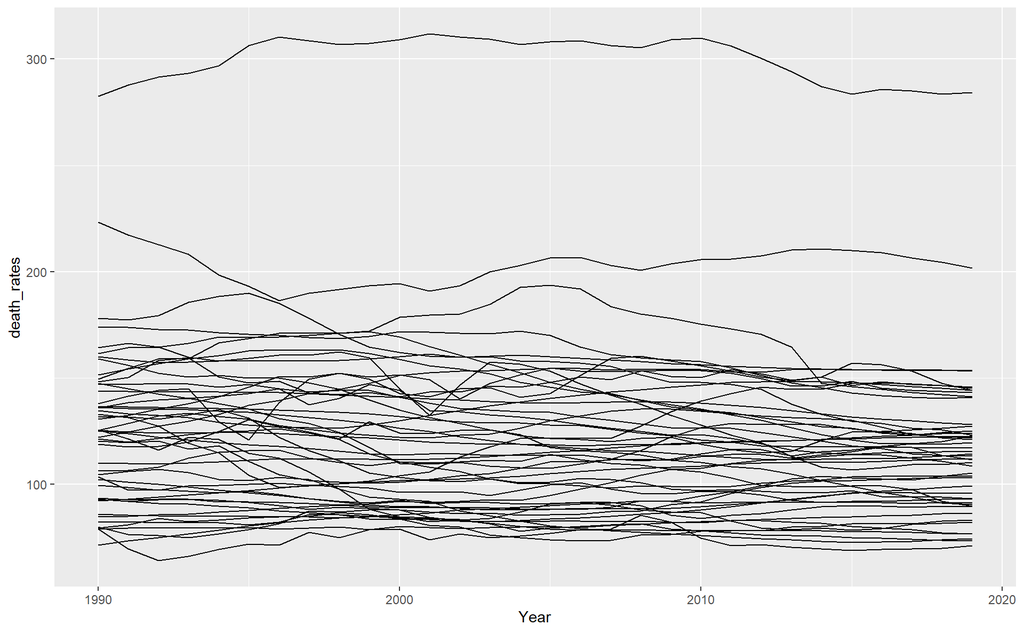

```r
ggplot(data = cancer_rates_asia,
       aes(x = Year,
           y = death_rates))+
  geom_line(
    aes(group = Entity))
```

# Clustering

```r
cancer_rates_asia_2000 <- cancer_rates_asia %>%
  filter(
    Year >= 2000
  )

# kita buat clustering
library(factoextra)
# package untuk clustering
library(dtw)
library(dtwclust)

#buat data dist
data_dist <- cancer_rates_asia_2000 %>%
  pivot_wider(
    names_from = Year,
    values_from = death_rates)
daftar_negara <- data_dist$Entity


data_dist <- data_dist %>%
  select(-Entity,-Code) %>%
  #jadikan matriks
  as.matrix.data.frame()
rownames(data_dist) <- daftar_negara

head(data_dist)
```

```
                 2000      2001      2002      2003      2004      2005
Afghanistan 160.05877 161.33393 159.79510 160.30908 160.71059 160.12203
Armenia     141.37174 143.40788 143.52790 146.27236 145.84561 148.06108
Bahrain     145.10823 132.45043 146.89095 157.68251 156.49104 153.18940
Bangladesh   92.53221  91.16685  91.52619  91.59701  90.71685  90.96496
Bhutan       80.21583  79.75748  79.28397  79.87919  79.96350  80.06968
Brunei      194.51388 190.99385 193.47590 199.89957 202.85346 206.37847
                 2006      2007      2008      2009      2010      2011
Afghanistan 159.35130 158.47711 157.77623 156.93582 156.37046 155.61743
Armenia     150.47678 149.25360 153.33795 153.88633 153.45661 152.19701
Bahrain     147.33594 141.97403 137.81209 132.46515 127.92045 123.31921
Bangladesh   91.50686  90.35273  88.12269  87.15799  86.86690  82.71911
Bhutan       79.81200  80.76474  81.25194  81.98104  82.58967  83.09331
Brunei      206.65499 203.07895 200.66663 203.84213 205.79391 206.11072
                 2012      2013      2014      2015      2016      2017
Afghanistan 155.09352 154.51398 154.31505 154.05708 153.92843 154.03673
Armenia     149.89929 146.15623 146.15735 148.45665 145.14974 144.31590
Bahrain     119.75012 113.07115 108.09284 106.98452 107.94567 109.49641
Bangladesh   79.54080  78.90169  79.49876  78.63981  79.23771  81.22940
Bhutan       83.49137  83.97331  84.43975  84.86770  85.20873  85.54343
Brunei      207.42709 210.27808 210.65936 210.06007 208.93026 206.43116
                 2018      2019
Afghanistan 153.90476 153.29780
Armenia     143.82129 143.19294
Bahrain     109.49737 110.44014
Bangladesh   81.86914  82.29159
Bhutan       86.19890  86.62527
Brunei      204.45795 201.71152
```

```r
# menentukan banyaknya cluster
cluster_ts <- function(k) {
  res_clust <- tsclust(
    series = data_dist,
    type = "hierarchical",
    k = k,
    distance = "DTW",
    control = hierarchical_control(
      # pakai complete linkage
      method = "average"
    )
  )
  return(cvi(res_clust))
}

hasil <- sapply(2:10, FUN = function(x) {
  cluster_ts(x)
})

colnames(hasil) <- paste(
  "k_",
  seq(2, 10)
)

hasil
```

```
              k_ 2      k_ 3        k_ 4        k_ 5        k_ 6        k_ 7
Sil     0.81432591 0.6102285  0.57427163  0.58998275  0.43906069  0.41527502
SF      0.00000000 0.0000000  0.00000000  0.00000000  0.00000000  0.00000000
CH     10.41012175 8.3821889 27.31890655 36.11698573 30.75372386 32.13208456
DB      0.09401652 0.1501431  0.25952736  0.38584948  0.35901237  0.53057977
DBstar  0.09401652 0.1754295  0.27013572  0.39672931  0.40561662  0.64395125
D       0.74195698 0.2592804  0.06760283  0.10731772  0.12492202  0.13525034
COP     0.17342550 0.1222861  0.05476223  0.03038517  0.02874002  0.02492059
              k_ 8        k_ 9       k_ 10
Sil     0.44357445  0.37917148  0.42871352
SF      0.00000000  0.00000000  0.00000000
CH     29.23006706 33.76758316 36.62871431
DB      0.44591337  0.48263828  0.53829059
DBstar  0.62976137  0.66177741  0.58086566
D       0.13525034  0.09049468  0.14652283
COP     0.02027823  0.01609934  0.01325979
```

- “Sil”: Silhouette index (Rousseeuw (1987); to be maximized).
- “D”: Dunn index (Arbelaitz et al. (2013); to be maximized).
- “COP”: COP index (Arbelaitz et al. (2013); to be minimized).
- “DB”: Davies-Bouldin index (Arbelaitz et al. (2013); to be minimized).
- “DBstar”: Modified Davies-Bouldin index (DB*) (Kim and Ramakrishna (2005); to be minimized).
- “CH”: Calinski-Harabasz index (Arbelaitz et al. (2013); to be maximized).
- “SF”: Score Function (Saitta et al. (2007); to be maximized; see notes).

```r
set.seed(200)
# buat cluster hierarchical dengan dist DTW dan linkage complete
model_cluster <- tsclust(
  series = data_dist,
  type = "hierarchical",
  k = 5,
  distance = "DTW",
  control = hierarchical_control(
    # pakai complete linkage
    method = "average"
  )
)

model_cluster
```

```
hierarchical clustering with 5 clusters
Using dtw distance
Using PAM (Hierarchical) centroids
Using method average

Time required for analysis:
   user  system elapsed
   1.10    0.00    1.09

Cluster sizes with average intra-cluster distance:

  size  av_dist
1   13 211.2353
2   17 167.4916
3    1   0.0000
4   16 177.7977
5    1   0.0000
```

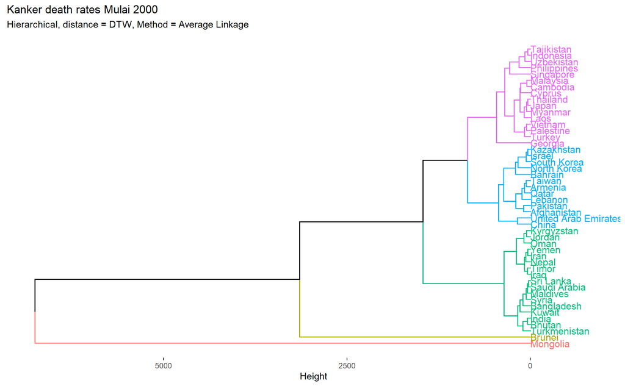

```r
dendrogram <- fviz_dend(model_cluster,horiz = T,
  # misal 4 cluster
  k = 5)+
  labs(title = "Kanker death rates Mulai 2000",
       subtitle = "Hierarchical, distance = DTW, Method = Average Linkage")
dendrogram
```

# Load Data

```r
library(tidyverse)

cancer_rates <- read_csv("Data/cancer-death-rates.csv")
cancer_rates <- cancer_rates %>%
  rename(
    "death_rates" = `Deaths - Neoplasms - Sex: Both - Age: Age-standardized (Rate)`
  )

cancer_rates %>%
  filter(
    str_detect(Entity, "ian")
  )
```

```
# A tibble: 30 x 4
   Entity                   Code   Year death_rates
   <chr>                    <chr> <dbl>       <dbl>
 1 Northern Mariana Islands MNP    1990        181.
 2 Northern Mariana Islands MNP    1991        180.
 3 Northern Mariana Islands MNP    1992        179.
 4 Northern Mariana Islands MNP    1993        178.
 5 Northern Mariana Islands MNP    1994        176.
 6 Northern Mariana Islands MNP    1995        176.
 7 Northern Mariana Islands MNP    1996        175.
 8 Northern Mariana Islands MNP    1997        175.
 9 Northern Mariana Islands MNP    1998        175.
10 Northern Mariana Islands MNP    1999        170.
# ... with 20 more rows
```

```r
asia <- readxl::read_xlsx("Data/AsiaEntity.xlsx")
asia
```

```
# A tibble: 48 x 1
   Entity
   <chr>
 1 Afghanistan
 2 Armenia
 3 Bahrain
 4 Bangladesh
 5 Bhutan
 6 Brunei
 7 Cambodia
 8 China
 9 Cyprus
10 Georgia
# ... with 38 more rows
```

```r
length(asia$Entity)
```

```
[1] 48
```

```r
cancer_rates_asia <- asia %>%
  left_join(cancer_rates)
cancer_rates_asia
```

```
# A tibble: 1,440 x 4
   Entity      Code   Year death_rates
   <chr>       <chr> <dbl>       <dbl>
 1 Afghanistan AFG    1990        160.
 2 Afghanistan AFG    1991        158.
 3 Afghanistan AFG    1992        157.
 4 Afghanistan AFG    1993        158.
 5 Afghanistan AFG    1994        158.
 6 Afghanistan AFG    1995        158.
 7 Afghanistan AFG    1996        158.
 8 Afghanistan AFG    1997        158.
 9 Afghanistan AFG    1998        158.
10 Afghanistan AFG    1999        159.
# ... with 1,430 more rows
```

```r
length(unique(cancer_rates_asia$Entity))
```

```
[1] 48
```

# Plot time series

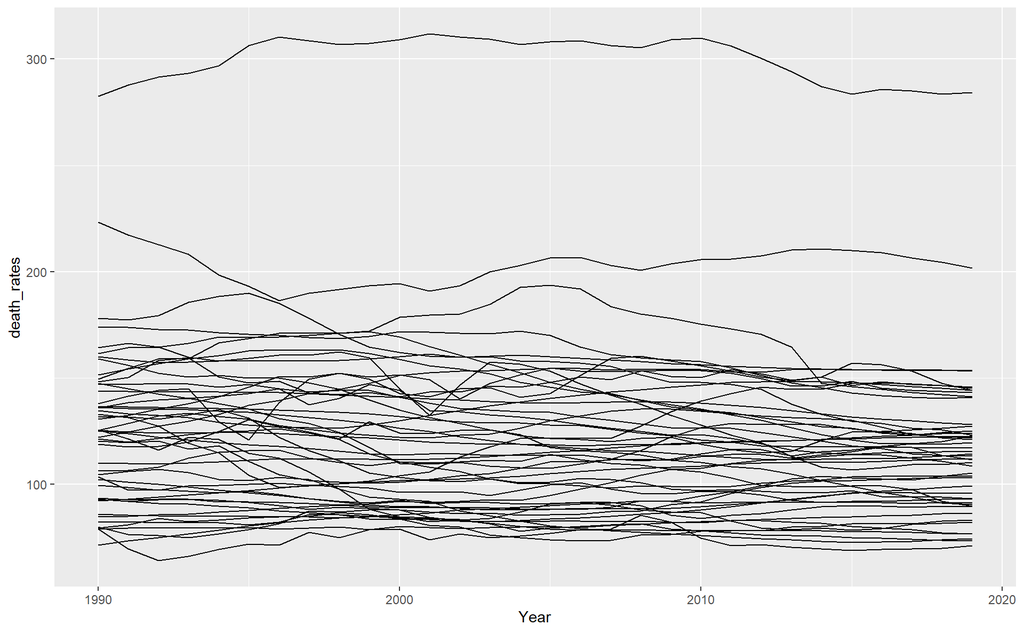

```r
ggplot(data = cancer_rates_asia,
       aes(x = Year,
           y = death_rates))+
  geom_line(
    aes(group = Entity))
```

# Clustering

```r
cancer_rates_asia_2000 <- cancer_rates_asia %>%
  filter(
    Year >= 2000
  )

# kita buat clustering
library(factoextra)
# package untuk clustering
library(dtw)
library(dtwclust)

#buat data dist
data_dist <- cancer_rates_asia_2000 %>%
  pivot_wider(
    names_from = Year,
    values_from = death_rates)
daftar_negara <- data_dist$Entity


data_dist <- data_dist %>%
  select(-Entity,-Code) %>%
  #jadikan matriks
  as.matrix.data.frame()
rownames(data_dist) <- daftar_negara

head(data_dist)
```

```
                 2000      2001      2002      2003      2004      2005
Afghanistan 160.05877 161.33393 159.79510 160.30908 160.71059 160.12203
Armenia     141.37174 143.40788 143.52790 146.27236 145.84561 148.06108
Bahrain     145.10823 132.45043 146.89095 157.68251 156.49104 153.18940
Bangladesh   92.53221  91.16685  91.52619  91.59701  90.71685  90.96496
Bhutan       80.21583  79.75748  79.28397  79.87919  79.96350  80.06968
Brunei      194.51388 190.99385 193.47590 199.89957 202.85346 206.37847
                 2006      2007      2008      2009      2010      2011
Afghanistan 159.35130 158.47711 157.77623 156.93582 156.37046 155.61743
Armenia     150.47678 149.25360 153.33795 153.88633 153.45661 152.19701
Bahrain     147.33594 141.97403 137.81209 132.46515 127.92045 123.31921
Bangladesh   91.50686  90.35273  88.12269  87.15799  86.86690  82.71911
Bhutan       79.81200  80.76474  81.25194  81.98104  82.58967  83.09331
Brunei      206.65499 203.07895 200.66663 203.84213 205.79391 206.11072
                 2012      2013      2014      2015      2016      2017
Afghanistan 155.09352 154.51398 154.31505 154.05708 153.92843 154.03673
Armenia     149.89929 146.15623 146.15735 148.45665 145.14974 144.31590
Bahrain     119.75012 113.07115 108.09284 106.98452 107.94567 109.49641
Bangladesh   79.54080  78.90169  79.49876  78.63981  79.23771  81.22940
Bhutan       83.49137  83.97331  84.43975  84.86770  85.20873  85.54343
Brunei      207.42709 210.27808 210.65936 210.06007 208.93026 206.43116
                 2018      2019
Afghanistan 153.90476 153.29780
Armenia     143.82129 143.19294
Bahrain     109.49737 110.44014
Bangladesh   81.86914  82.29159
Bhutan       86.19890  86.62527
Brunei      204.45795 201.71152
```

```r
# menentukan banyaknya cluster
cluster_ts <- function(k) {
  res_clust <- tsclust(
    series = data_dist,
    type = "hierarchical",
    k = k,
    distance = "DTW",
    control = hierarchical_control(
      # pakai complete linkage
      method = "average"
    )
  )
  return(cvi(res_clust))
}

hasil <- sapply(2:10, FUN = function(x) {
  cluster_ts(x)
})

colnames(hasil) <- paste(
  "k_",
  seq(2, 10)
)

hasil
```

```
              k_ 2      k_ 3        k_ 4        k_ 5        k_ 6        k_ 7
Sil     0.81432591 0.6102285  0.57427163  0.58998275  0.43906069  0.41527502
SF      0.00000000 0.0000000  0.00000000  0.00000000  0.00000000  0.00000000
CH     10.41012175 8.3821889 27.31890655 36.11698573 30.75372386 32.13208456
DB      0.09401652 0.1501431  0.25952736  0.38584948  0.35901237  0.53057977
DBstar  0.09401652 0.1754295  0.27013572  0.39672931  0.40561662  0.64395125
D       0.74195698 0.2592804  0.06760283  0.10731772  0.12492202  0.13525034
COP     0.17342550 0.1222861  0.05476223  0.03038517  0.02874002  0.02492059
              k_ 8        k_ 9       k_ 10
Sil     0.44357445  0.37917148  0.42871352
SF      0.00000000  0.00000000  0.00000000
CH     29.23006706 33.76758316 36.62871431
DB      0.44591337  0.48263828  0.53829059
DBstar  0.62976137  0.66177741  0.58086566
D       0.13525034  0.09049468  0.14652283
COP     0.02027823  0.01609934  0.01325979
```

- “Sil”: Silhouette index (Rousseeuw (1987); to be maximized).
- “D”: Dunn index (Arbelaitz et al. (2013); to be maximized).
- “COP”: COP index (Arbelaitz et al. (2013); to be minimized).
- “DB”: Davies-Bouldin index (Arbelaitz et al. (2013); to be minimized).
- “DBstar”: Modified Davies-Bouldin index (DB*) (Kim and Ramakrishna (2005); to be minimized).
- “CH”: Calinski-Harabasz index (Arbelaitz et al. (2013); to be maximized).
- “SF”: Score Function (Saitta et al. (2007); to be maximized; see notes).

```r
set.seed(200)
# buat cluster hierarchical dengan dist DTW dan linkage complete
model_cluster <- tsclust(
  series = data_dist,
  type = "hierarchical",
  k = 5,
  distance = "DTW",
  control = hierarchical_control(
    # pakai complete linkage
    method = "average"
  )
)

model_cluster
```

```
hierarchical clustering with 5 clusters
Using dtw distance
Using PAM (Hierarchical) centroids
Using method average

Time required for analysis:
   user  system elapsed
   1.09    0.00    1.10

Cluster sizes with average intra-cluster distance:

  size  av_dist
1   13 211.2353
2   17 167.4916
3    1   0.0000
4   16 177.7977
5    1   0.0000
```

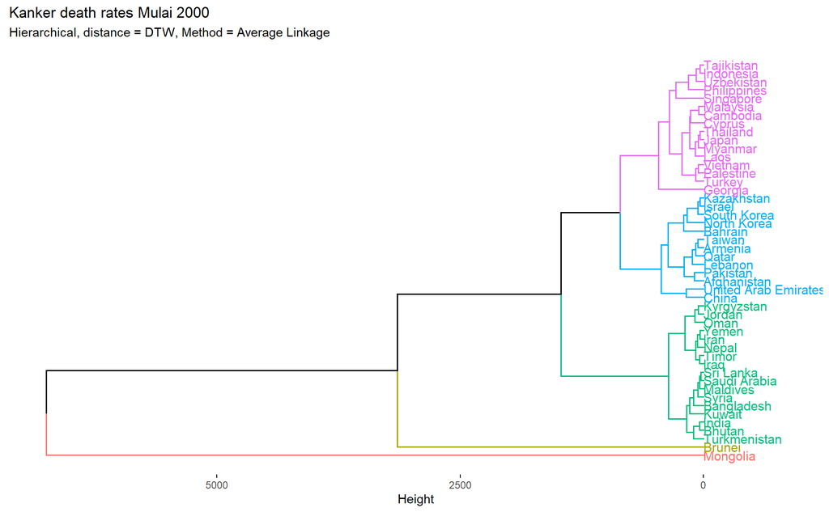

```r
dendrogram <- fviz_dend(model_cluster,horiz = T,
  # misal 4 cluster
  k = 5)+
  labs(title = "Kanker death rates Mulai 2000",
       subtitle = "Hierarchical, distance = DTW, Method = Average Linkage")
dendrogram
```

Urutan dari Tingkatannya : Oranye, Kuning, Biru, Pink, Hijau

```r
cluster_result <- readxl::read_excel("Data/cluster_result.xlsx")
cluster_result
```

```
# A tibble: 48 x 2
   Entity       cluster
   <chr>          <dbl>
 1 Mongolia           1
 2 Brunei             2
 3 Turkmenistan       5
 4 Bhutan             5
 5 India              5
 6 Kuwait             5
 7 Bangladesh         5
 8 Syria              5
 9 Maldives           5
10 Saudi Arabia       5
# ... with 38 more rows
```

```r
cancer_rates_asia_2000 <- cancer_rates_asia_2000 %>%
  left_join(cluster_result) %>%
  mutate(
    cluster = as.factor(cluster)
  )
cancer_rates_asia_2000
```

```
# A tibble: 960 x 5
   Entity      Code   Year death_rates cluster
   <chr>       <chr> <dbl>       <dbl> <fct>
 1 Afghanistan AFG    2000        160. 3
 2 Afghanistan AFG    2001        161. 3
 3 Afghanistan AFG    2002        160. 3
 4 Afghanistan AFG    2003        160. 3
 5 Afghanistan AFG    2004        161. 3
 6 Afghanistan AFG    2005        160. 3
 7 Afghanistan AFG    2006        159. 3
 8 Afghanistan AFG    2007        158. 3
 9 Afghanistan AFG    2008        158. 3
10 Afghanistan AFG    2009        157. 3
# ... with 950 more rows
```

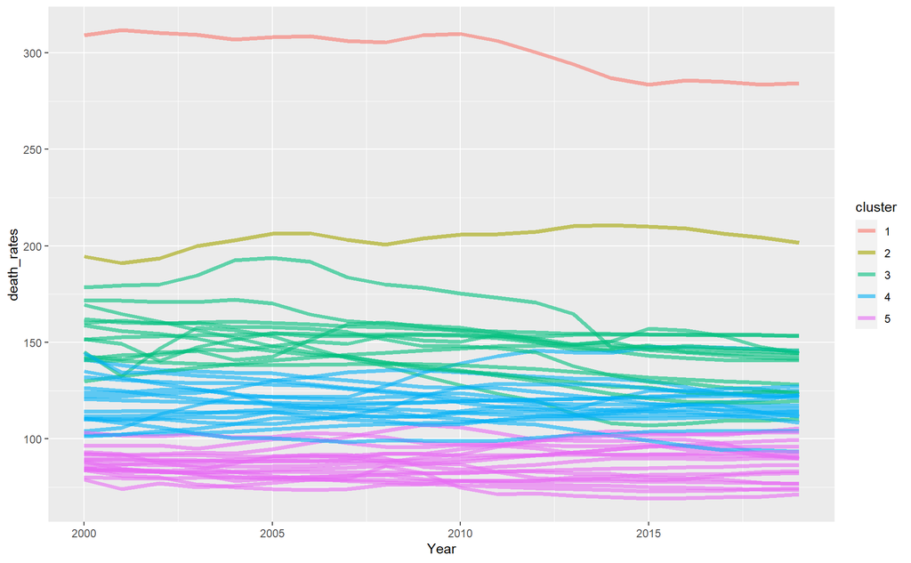

```r
ggplot(data = cancer_rates_asia_2000)+
  geom_line(
    aes(x = Year,
        y = death_rates,
        group = Entity,
        color = cluster),
    size = 1.5,
    alpha = 0.6)
```

Outliernya cukup dikit, representasi cluster bisa diambil dari rata-rata atau median dari setiap cluster setiap tahun. Kita pakai rata-rata.

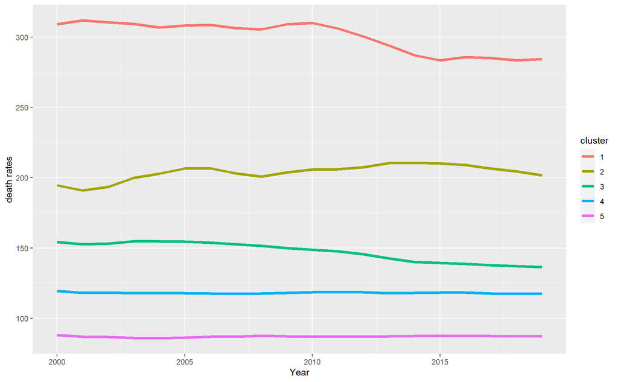

```r
cluster_death_rates <- cancer_rates_asia_2000 %>%
  group_by(cluster, Year) %>%
  summarize(
    death_rates = mean(death_rates)) %>%
  ungroup()

ggplot(data = cluster_death_rates)+
  geom_line(
    aes(x = Year,
        y = death_rates,
        color = cluster),
    size = 1.5)+
  labs(
    y = "death rates")
```

# Train test split

Kita split datanya, untuk data test diambil yang tahun 2017, 2018, 2019 (3 tahun yang paling akhir).

```r
train <- cluster_death_rates %>%
  filter(
    Year <=2016)
test <- cluster_death_rates %>%
  filter(
    Year >= 2017)
```

# Modelling

Buat model ANN untuk setiap cluster

```r
library(forecast)

#pakai data train
list_df_train <- split(train,
                 train$cluster)
#cukup panjang, jadi intinya bikin list df untuk tiap cluster.
# contohnya untuk cluster 1 gini
list_df_train[[1]]
```

```
# A tibble: 17 x 3
   cluster  Year death_rates
   <fct>   <dbl>       <dbl>
 1 1        2000        309.
 2 1        2001        312.
 3 1        2002        310.
 4 1        2003        309.
 5 1        2004        307.
 6 1        2005        308.
 7 1        2006        309.
 8 1        2007        306.
 9 1        2008        305.
10 1        2009        309.
11 1        2010        310.
12 1        2011        306.
13 1        2012        300.
14 1        2013        294.
15 1        2014        287.
16 1        2015        284.
17 1        2016        286.
```

## Cek residualnya

```r
library(nortest)
cek_residual <- function(model, i) {

  #cek visual
  checkresiduals(model)

  #cek normalitas
  print(shapiro.test(model$residuals))
  print(lillie.test(model$residuals))

  #cek homogenitas
  print(nortsTest::arch.test(
    model$residuals[!is.na(model$residuals)]
    )
  )

  #forecastnya
  prediksi <- forecast(model) %>%
    as_tibble()
  print(prediksi)

  #akurasi data train
  print(accuracy(model))

  #akurasi berdasarkan data test
  test_i <- test %>%
    filter(
      cluster == i)
  print(test_i)

  #ambil yang 3 tahun ke depan
  three_years <- prediksi$`Point Forecast`[1:3]
  print("MAE test set")
  print(DescTools::MAE(test_i$death_rates, three_years))
  print("MAPE test set")
  print(DescTools::MAPE(test_i$death_rates, three_years))
  print("RMSE test set")
  print(DescTools::RMSE(test_i$death_rates, three_years))
}
```

## Cluster 1

```r
ann_c1 <- nnetar(
  ts(list_df_train[[1]]$death_rates,
     start = 2000),
  )
ann_c1
```

```
Series: ts(list_df_train[[1]]$death_rates, start = 2000)
Model:  NNAR(2,2)
Call:   nnetar(y = ts(list_df_train[[1]]$death_rates, start = 2000))

Average of 20 networks, each of which is
a 2-2-1 network with 9 weights
options were - linear output units

sigma^2 estimated as 1.741
```

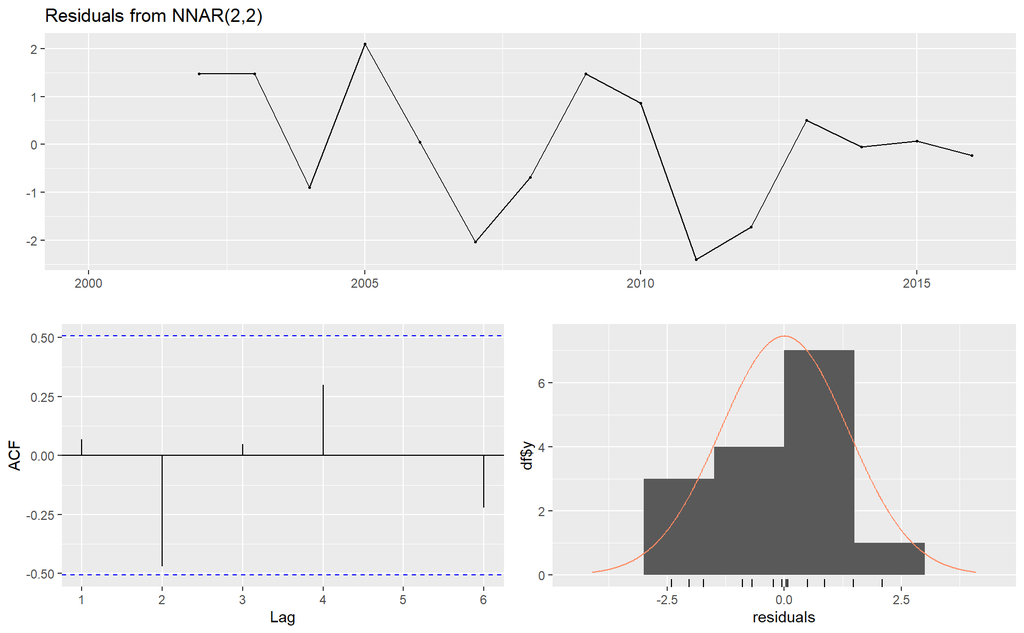

```
    Shapiro-Wilk normality test

data:  model$residuals
W = 0.95671, p-value = 0.6355


    Lilliefors (Kolmogorov-Smirnov) normality test

data:  model$residuals
D = 0.12617, p-value = 0.7506


    Box-Ljung test

data:  y^2
X-squared = 1.5315, df = 2, p-value = 0.465
alternative hypothesis: y is heteroscedastic

# A tibble: 10 x 1
   `Point Forecast`
              <dbl>
 1             308.
 2             319.
 3             312.
 4             296.
 5             284.
 6             282.
 7             289.
 8             313.
 9             315.
10             309.
                       ME     RMSE      MAE          MPE      MAPE      MASE
Training set 0.0002758745 1.319636 1.068167 -0.002071525 0.3489959 0.3747901
                   ACF1
Training set 0.06871225
# A tibble: 3 x 3
  cluster  Year death_rates
  <fct>   <dbl>       <dbl>
1 1        2017        285.
2 1        2018        284.
3 1        2019        284.
[1] "MAE test set"
[1] 28.56954
[1] "MAPE test set"
[1] 0.09108877
[1] "RMSE test set"
[1] 29.0468
```

```r
cek_residual(ann_c1, 1)
```

## Cluster 2

```r
ann_c2 <- nnetar(
  ts(list_df_train[[2]]$death_rates,
     start = 2000),
  )
ann_c2
```

```
Series: ts(list_df_train[[2]]$death_rates, start = 2000)
Model:  NNAR(2,2)
Call:   nnetar(y = ts(list_df_train[[2]]$death_rates, start = 2000))

Average of 20 networks, each of which is
a 2-2-1 network with 9 weights
options were - linear output units

sigma^2 estimated as 1.879
```

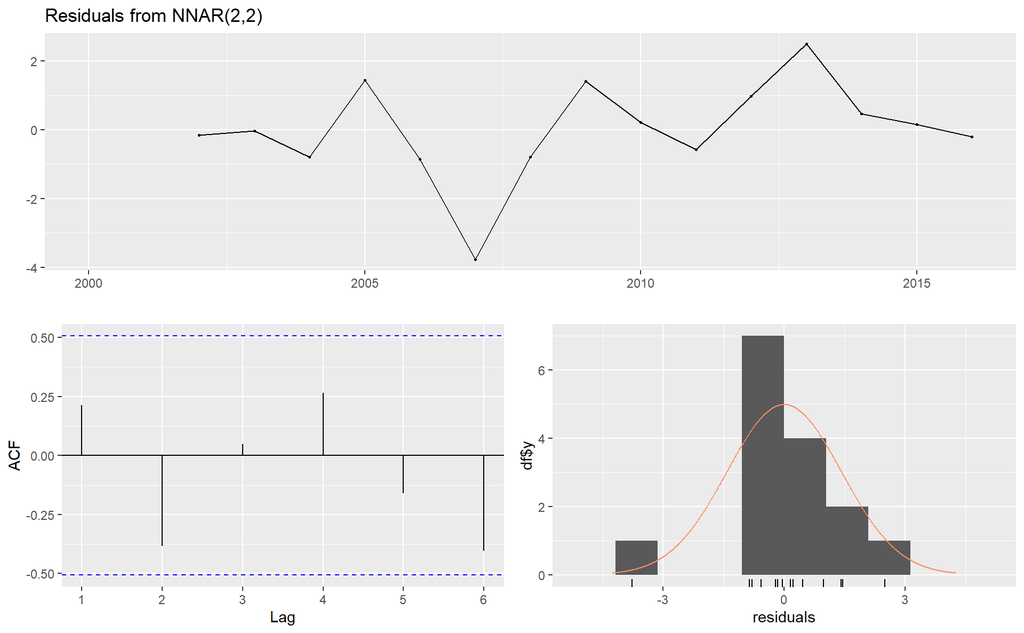

```
    Shapiro-Wilk normality test

data:  model$residuals
W = 0.90991, p-value = 0.135


    Lilliefors (Kolmogorov-Smirnov) normality test

data:  model$residuals
D = 0.20681, p-value = 0.08386


    Box-Ljung test

data:  y^2
X-squared = 0.29163, df = 2, p-value = 0.8643
alternative hypothesis: y is heteroscedastic

# A tibble: 10 x 1
   `Point Forecast`
              <dbl>
 1             208.
 2             208.
 3             207.
 4             207.
 5             207.
 6             207.
 7             207.
 8             207.
 9             207.
10             207.
                       ME     RMSE       MAE          MPE      MAPE      MASE
Training set -0.003052377 1.370876 0.9575236 -0.006390056 0.4659585 0.4152837
                  ACF1
Training set 0.2131492
# A tibble: 3 x 3
  cluster  Year death_rates
  <fct>   <dbl>       <dbl>
1 2        2017        206.
2 2        2018        204.
3 2        2019        202.
[1] "MAE test set"
[1] 3.386191
[1] "MAPE test set"
[1] 0.01632476
[1] "RMSE test set"
[1] 3.742521
```

```r
cek_residual(ann_c2, 2)
```

## Cluster 3

```r
ann_c3 <- nnetar(
  ts(list_df_train[[3]]$death_rates,
     start = 2000),
  )
ann_c3
```

```
Series: ts(list_df_train[[3]]$death_rates, start = 2000)
Model:  NNAR(1,1)
Call:   nnetar(y = ts(list_df_train[[3]]$death_rates, start = 2000))

Average of 20 networks, each of which is
a 1-1-1 network with 4 weights
options were - linear output units

sigma^2 estimated as 0.5334
```

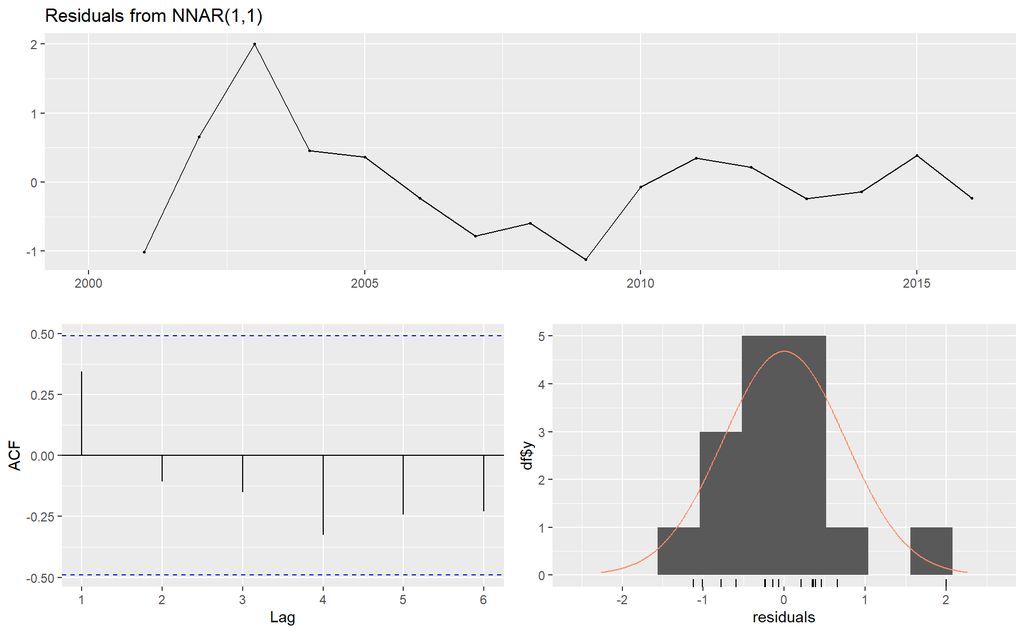

```
    Shapiro-Wilk normality test

data:  model$residuals
W = 0.92206, p-value = 0.182


    Lilliefors (Kolmogorov-Smirnov) normality test

data:  model$residuals
D = 0.14643, p-value = 0.4756


    Box-Ljung test

data:  y^2
X-squared = 0.23554, df = 2, p-value = 0.8889
alternative hypothesis: y is heteroscedastic

# A tibble: 10 x 1
   `Point Forecast`
              <dbl>
 1             139.
 2             139.
 3             139.
 4             139.
 5             139.
 6             139.
 7             139.
 8             139.
 9             139.
10             139.
                        ME      RMSE       MAE          MPE      MAPE      MASE
Training set -5.902328e-07 0.7303467 0.5534141 -0.002298589 0.3665545 0.4542579
                  ACF1
Training set 0.3438129
# A tibble: 3 x 3
  cluster  Year death_rates
  <fct>   <dbl>       <dbl>
1 3        2017        138.
2 3        2018        137.
3 3        2019        136.
[1] "MAE test set"
[1] 1.58018
[1] "MAPE test set"
[1] 0.01140043
[1] "RMSE test set"
[1] 1.681327
```

```r
cek_residual(ann_c3, 3)
```

## Cluster 4

```r
ann_c4 <- nnetar(
  ts(list_df_train[[4]]$death_rates,
     start = 2000),
  )
ann_c4
```

```
Series: ts(list_df_train[[4]]$death_rates, start = 2000)
Model:  NNAR(1,1)
Call:   nnetar(y = ts(list_df_train[[4]]$death_rates, start = 2000))

Average of 20 networks, each of which is
a 1-1-1 network with 4 weights
options were - linear output units

sigma^2 estimated as 0.07715
```

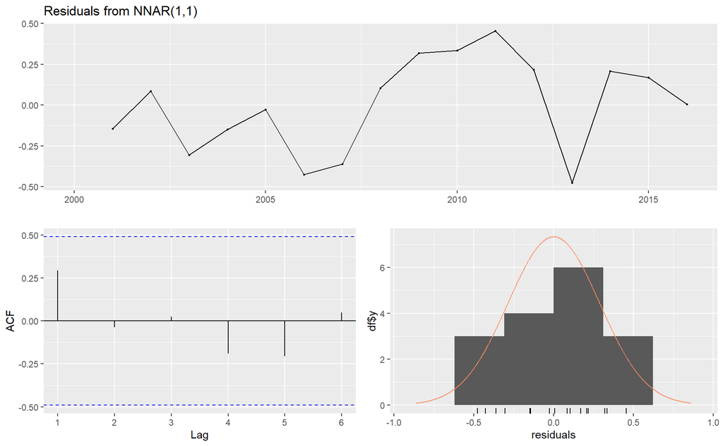

```
    Shapiro-Wilk normality test

data:  model$residuals
W = 0.95654, p-value = 0.5997


    Lilliefors (Kolmogorov-Smirnov) normality test

data:  model$residuals
D = 0.11569, p-value = 0.8206


    Box-Ljung test

data:  y^2
X-squared = 0.059859, df = 2, p-value = 0.9705
alternative hypothesis: y is heteroscedastic

# A tibble: 10 x 1
   `Point Forecast`
              <dbl>
 1             118.
 2             118.
 3             118.
 4             118.
 5             118.
 6             118.
 7             118.
 8             118.
 9             118.
10             118.
                       ME      RMSE       MAE           MPE     MAPE      MASE
Training set 4.628002e-06 0.2777523 0.2366554 -0.0005496551 0.200499 0.7013042
                  ACF1
Training set 0.2942208
# A tibble: 3 x 3
  cluster  Year death_rates
  <fct>   <dbl>       <dbl>
1 4        2017        118.
2 4        2018        117.
3 4        2019        117.
[1] "MAE test set"
[1] 0.74583
[1] "MAPE test set"
[1] 0.00630795
[1] "RMSE test set"
[1] 0.7625906
```

```r
cek_residual(ann_c4, 4)
```

## Cluster 5

```r
ann_c5 <- nnetar(
  ts(list_df_train[[5]]$death_rates,
     start = 2000),
  )
ann_c5
```

```
Series: ts(list_df_train[[5]]$death_rates, start = 2000)
Model:  NNAR(1,1)
Call:   nnetar(y = ts(list_df_train[[5]]$death_rates, start = 2000))

Average of 20 networks, each of which is
a 1-1-1 network with 4 weights
options were - linear output units

sigma^2 estimated as 0.09902
```

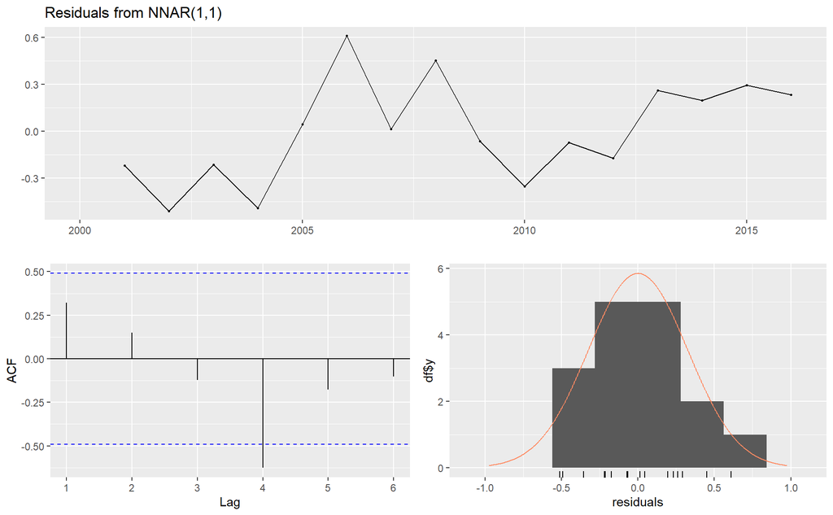

```
    Shapiro-Wilk normality test

data:  model$residuals
W = 0.97527, p-value = 0.9151


    Lilliefors (Kolmogorov-Smirnov) normality test

data:  model$residuals
D = 0.10194, p-value = 0.9279


    Box-Ljung test

data:  y^2
X-squared = 17.225, df = 2, p-value = 0.0001818
alternative hypothesis: y is heteroscedastic

# A tibble: 10 x 1
   `Point Forecast`
              <dbl>
 1             87.2
 2             87.2
 3             87.2
 4             87.2
 5             87.2
 6             87.2
 7             87.2
 8             87.2
 9             87.2
10             87.2
                       ME      RMSE       MAE          MPE      MAPE      MASE
Training set 1.288246e-05 0.3146763 0.2623837 -0.001299837 0.3020922 0.7168845
                  ACF1
Training set 0.3207329
# A tibble: 3 x 3
  cluster  Year death_rates
  <fct>   <dbl>       <dbl>
1 5        2017        87.4
2 5        2018        87.2
3 5        2019        87.3
[1] "MAE test set"
[1] 0.09194739
[1] "MAPE test set"
[1] 0.001054582
[1] "RMSE test set"
[1] 0.114664
```

```r
cek_residual(ann_c5, 5)
```